# Apply Type Functions

Lauren Cappiello

10/4/2022

Loops are a great, relatively straightforward way to repeatedly execute a chunk of code. However, they aren’t especially efficient. Enter: the `apply` type function:

- `replicate()`
- `apply()`
- `lapply()`
- `sapply()`
- `tapply()`
- `mapply()`

These functions run code chunks in a non-sequential way that is often more efficient than a loop (as long as the elements in your object aren’t dependent on other elements in your object).

# `replicate()`

We will start with replicate because it’s arguably the easiest of these functions to use. The `replicate` function repeats a function call `n` times.

```r
replicate(n=4, "Hello")
```

```
## [1] "Hello" "Hello" "Hello" "Hello"
```

```r
replicate(10, factorial(7))
```

```
##  [1] 5040 5040 5040 5040 5040 5040 5040 5040 5040 5040
```

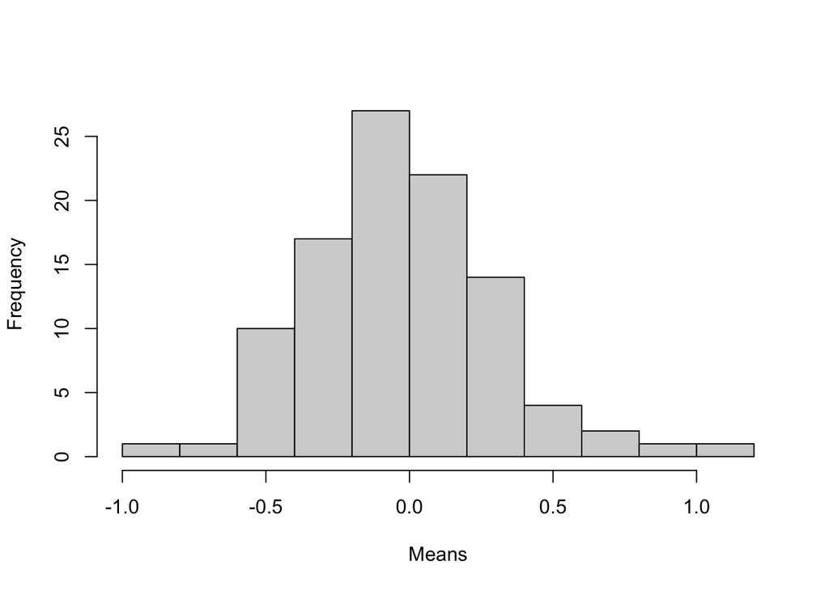

```r
# histogram of the means from 100 random samples of size n=10 from a standard normal distribution
hist(replicate(100, mean(rnorm(10))),
     main = "", xlab="Means")
```

### A Similar Function for Simple Value Replication

The function `rep` replicates the values in the first argument. This is *not* part of the `apply` family, but may serve a similar purpose to `replicate`.

Suppose I want to represent all of the possible combinations when rolling two four-sided dice.

```r
v1 <- rep(1:4, times=4) # replicate the sequence 1:4, four times
v2 <- rep(1:4, each=4) # replicate 1:4, with each number replicated 4 times (in a row)
data.frame(v1, v2)
```

```
##    v1 v2
## 1   1  1
## 2   2  1
## 3   3  1
## 4   4  1
## 5   1  2
## 6   2  2
## 7   3  2
## 8   4  2
## 9   1  3
## 10  2  3
## 11  3  3
## 12  4  3
## 13  1  4
## 14  2  4
## 15  3  4
## 16  4  4
```

# `apply()`

The `apply` function applies a given function to the rows or columns of matrices (or arrays). It assembles the returned values into a vector, array, or list, which it returns.

The `apply()` arguments:

- `X`: an array (matrix)
- `MARGIN`
  - `1` indicates rows
  - ‘2’ indicates columns
  - `c(1,2)` indicates rows and columns
- `FUN`: the function to be applied
- `...`: additional arguments to be passed to `FUN`

```r
data <- matrix(1:9, nrow=3, ncol=3)
# the following is equivalent to the command: colMeans(data)
apply(data, 2, mean) # data, columns, mean --> get column means
```

```
## [1] 2 5 8
```

```r
# the following is equivalent to the command: rowSums(data)
apply(data, 1, sum) # data, rows, sum --> get row sums
```

```
## [1] 12 15 18
```

We can also use `apply` functions on user-defined functions.

```r
# Define the function within the apply statement:
apply(data, 2, function(x){
    y <- sum(x)^2 # sum of the input vector (here a column) squared
    return(y)
  }
)
```

```
## [1]  36 225 576
```

```r
# Define the function outside of the apply statement:
fn <- function(x){
    y <- sum(x)^2 # sum of the input vector (here a column) squared
    return(y)
}
apply(data, 2, fn)
```

```
## [1]  36 225 576
```

The values that `apply()` returns depends on the function `FUN`.

- If `FUN` returns an element of length 1, then `apply` will return a vector.
- If `FUN` always returns an element of length $n>1$, then `apply` will return a matrix with n rows, and the number of columns will correspond to how many rows/columns were iterated over.
- Finally, if `FUN` returns an object that would vary in length, then `apply` will return a list where each element corresponds to a row or column that was iterated over.

In short, `apply` prioritizes returning a vector, array (matrix), and list (in that order). What is returned depends on the output of `FUN`.

Note: running `apply` on a data frame will cause R to convert the data frame using `as.matrix`. This is often not what we want, so be cautious doing that.

### Example: Extra Arguments, Array Output

```r
x <- cbind(x1 = 3, x2 = c(4:1, 2:5))

fun1 <- function(x, c1, c2){
  mean_vec <- c(mean(x[c1]), mean(x[c2]))
  return(mean_vec)
}

apply(x, 1, fun1,  c1 = "x1", c2 = c("x1","x2"))
```

```
##      [,1] [,2] [,3] [,4] [,5] [,6] [,7] [,8]
## [1,]  3.0    3  3.0    3  3.0    3  3.0    3
## [2,]  3.5    3  2.5    2  2.5    3  3.5    4
```

### Example: List Output

```r
mat <- matrix(c(-1, 1, 0,
                2, -2, 20,
                62,-2, -6), nrow = 3)

CheckPos <- function(Vec){
  # Subset values of Vec that are even
  PosVec <- Vec[Vec > 0]

  # Return only the even values
  return(PosVec)
}

# Check Positive values by column
apply(mat, 2, CheckPos)
```

```
## [[1]]
## [1] 1
##
## [[2]]
## [1]  2 20
##
## [[3]]
## [1] 62
```

### On Your Own

Use an apply function to find the interquartile range (`IQR()`) of each variable in the `ChickWeight` data. (This dataset is built into R.)

# `lapply()`

The `lapply` function is used to apply a function to each element of a list. It collects the returned values into another list, which it returns.

Arguments:

- `X`: a list
- `FUN`: the function to be applied
- `...`: additional arguments to be passed to `FUN`

```r
data_lst <- list(item1 = 1:5,
                item2 = seq(4,36,8),
                item3 = c(1,3,5,7,9))
data_vector <- 1:8

lapply(data_lst, sum)
```

```
## $item1
## [1] 15
##
## $item2
## [1] 100
##
## $item3
## [1] 25
```

```r
lapply(data_vector, sum) # lapply performs an `as.list` command on X if it's not already a list
```

```
## [[1]]
## [1] 1
##
## [[2]]
## [1] 2
##
## [[3]]
## [1] 3
##
## [[4]]
## [1] 4
##
## [[5]]
## [1] 5
##
## [[6]]
## [1] 6
##
## [[7]]
## [1] 7
##
## [[8]]
## [1] 8
```

```r
x <- list(a = 1:10,
          beta = exp(-3:3),
          logic = c(TRUE,FALSE,FALSE,TRUE))

# compute the list mean for each list element
lapply(x, mean)
```

```
## $a
## [1] 5.5
##
## $beta
## [1] 4.535125
##
## $logic
## [1] 0.5
```

Consider the built-in data set `iris`. If we use the `as.list()` function, each column is converted into an element of a list.

```r
head(iris)
```

```
##   Sepal.Length Sepal.Width Petal.Length Petal.Width Species
## 1          5.1         3.5          1.4         0.2  setosa
## 2          4.9         3.0          1.4         0.2  setosa
## 3          4.7         3.2          1.3         0.2  setosa
## 4          4.6         3.1          1.5         0.2  setosa
## 5          5.0         3.6          1.4         0.2  setosa
## 6          5.4         3.9          1.7         0.4  setosa
```

```r
str(as.list(iris))
```

```
## List of 5
##  $ Sepal.Length: num [1:150] 5.1 4.9 4.7 4.6 5 5.4 4.6 5 4.4 4.9 ...
##  $ Sepal.Width : num [1:150] 3.5 3 3.2 3.1 3.6 3.9 3.4 3.4 2.9 3.1 ...
##  $ Petal.Length: num [1:150] 1.4 1.4 1.3 1.5 1.4 1.7 1.4 1.5 1.4 1.5 ...
##  $ Petal.Width : num [1:150] 0.2 0.2 0.2 0.2 0.2 0.4 0.3 0.2 0.2 0.1 ...
##  $ Species     : Factor w/ 3 levels "setosa","versicolor",..: 1 1 1 1 1 1 1 1 1 1 ...
```

So if we use `lapply()` in this case, it will iterate over the *columns*. We can find all values within a variable that are greater than the variable mean (for columns 1-4, the numeric variables).

```r
lapply(iris[,1:4], function(column){
  big_values <- column[column > mean(column)]
  return(big_values)
})
```

```
## $Sepal.Length
##  [1] 7.0 6.4 6.9 6.5 6.3 6.6 5.9 6.0 6.1 6.7 6.2 5.9 6.1 6.3 6.1 6.4 6.6 6.8 6.7
## [20] 6.0 6.0 6.0 6.7 6.3 6.1 6.2 6.3 7.1 6.3 6.5 7.6 7.3 6.7 7.2 6.5 6.4 6.8 6.4
## [39] 6.5 7.7 7.7 6.0 6.9 7.7 6.3 6.7 7.2 6.2 6.1 6.4 7.2 7.4 7.9 6.4 6.3 6.1 7.7
## [58] 6.3 6.4 6.0 6.9 6.7 6.9 6.8 6.7 6.7 6.3 6.5 6.2 5.9
##
## $Sepal.Width
##  [1] 3.5 3.2 3.1 3.6 3.9 3.4 3.4 3.1 3.7 3.4 4.0 4.4 3.9 3.5 3.8 3.8 3.4 3.7 3.6
## [20] 3.3 3.4 3.4 3.5 3.4 3.2 3.1 3.4 4.1 4.2 3.1 3.2 3.5 3.6 3.4 3.5 3.2 3.5 3.8
## [39] 3.8 3.2 3.7 3.3 3.2 3.2 3.1 3.3 3.1 3.2 3.4 3.1 3.3 3.6 3.2 3.2 3.8 3.2 3.3
## [58] 3.2 3.8 3.4 3.1 3.1 3.1 3.1 3.2 3.3 3.4
##
## $Petal.Length
##  [1] 4.7 4.5 4.9 4.0 4.6 4.5 4.7 4.6 3.9 4.2 4.0 4.7 4.4 4.5 4.1 4.5 3.9 4.8 4.0
## [20] 4.9 4.7 4.3 4.4 4.8 5.0 4.5 3.8 3.9 5.1 4.5 4.5 4.7 4.4 4.1 4.0 4.4 4.6 4.0
## [39] 4.2 4.2 4.2 4.3 4.1 6.0 5.1 5.9 5.6 5.8 6.6 4.5 6.3 5.8 6.1 5.1 5.3 5.5 5.0
## [58] 5.1 5.3 5.5 6.7 6.9 5.0 5.7 4.9 6.7 4.9 5.7 6.0 4.8 4.9 5.6 5.8 6.1 6.4 5.6
## [77] 5.1 5.6 6.1 5.6 5.5 4.8 5.4 5.6 5.1 5.1 5.9 5.7 5.2 5.0 5.2 5.4 5.1
##
## $Petal.Width
##  [1] 1.4 1.5 1.5 1.3 1.5 1.3 1.6 1.3 1.4 1.5 1.4 1.3 1.4 1.5 1.5 1.8 1.3 1.5 1.2
## [20] 1.3 1.4 1.4 1.7 1.5 1.2 1.6 1.5 1.6 1.5 1.3 1.3 1.3 1.2 1.4 1.2 1.3 1.2 1.3
## [39] 1.3 1.3 2.5 1.9 2.1 1.8 2.2 2.1 1.7 1.8 1.8 2.5 2.0 1.9 2.1 2.0 2.4 2.3 1.8
## [58] 2.2 2.3 1.5 2.3 2.0 2.0 1.8 2.1 1.8 1.8 1.8 2.1 1.6 1.9 2.0 2.2 1.5 1.4 2.3
## [77] 2.4 1.8 1.8 2.1 2.4 2.3 1.9 2.3 2.5 2.3 1.9 2.0 2.3 1.8
```

### On Your Own

Use `lapply` to find the range for each item in the list `data_lst` (which should already be in your R environment from an earlier code chunk).

# `sapply()`

The `sapply` function works basically the same as the `lapply` function. The primary difference is that `sapply` attempts to simplify the result into a vector or matrix (instead of a list). This simplification works the same way as in `apply`.

```r
lapply(data_lst, sum) # returns a list
```

```
## $item1
## [1] 15
##
## $item2
## [1] 100
##
## $item3
## [1] 25
```

```r
sapply(data_lst, sum) # returns a vector
```

```
## item1 item2 item3
##    15   100    25
```

### On Your Own

Use `sapply` to find the range for each item in the list `data_lst`.

# `tapply()`

The `tapply` function breaks the data set up into groups and applies a function to each group.

Arguments:

- `X`: A 1 dimensional object
- `INDEX`: A grouping factor or a list of factors
- `FUN`: The function to be applied

```r
data = data.frame(name=c("Amy","Jose","Ray","Kim","Sam","Eve","Bob"),
                  age=c(24, 22, 21, 23, 20, 24, 21),
                  gender=factor(c("F","M","M","F","M","F","M")))
tapply(data$age, data$gender, min) # age, grouped by gender, min for each group
```

```
##  F  M
## 23 20
```

### On Your Own

For the `ChickWeight` data, use `tapply` find the mean weight for each chick.

# `mapply()`

The `mapply` function is a multivariate version of `sapply`. It applies `FUN` to the first elements of each `...` argument, the second elements, the third elements, and so on.

Arguments:

- `FUN`: The function to be applied
- `...`: Arguments to vectorize over (vectors or lists of strictly positive length, or all of zero length).

```r
mapply(rep, times = 1:4, x = 4:1)
```

```
## [[1]]
## [1] 4
##
## [[2]]
## [1] 3 3
##
## [[3]]
## [1] 2 2 2
##
## [[4]]
## [1] 1 1 1 1
```

More information and examples: http://adv-r.had.co.nz/Functionals.html